# LDA

Deviprasad Saka

2024-04-25

```r
library(MASS)
```

```r
library(ggplot2)
library(memisc)
library(ROCR)
library(dplyr)
library(klaR)
library(psych)
mydata <- read.csv("D:/Multivariate Analysis/Assignment-9/Ship_data.csv")
mydata
```

```
##          Hs    Power    tot_r         V       dist    hours        n         t
## 1  2.237650 16531.23 1102.055 10.516014   25.56750 2.295233 2.094407 0.2030426
## 2  2.255918 16550.69 1103.121  9.636495   49.94165 2.454985 2.094962 0.2090622
## 3  2.292786 16604.01 1106.018 11.246574   99.88330 2.340117 2.096530 0.2119333
## 4  2.330973 16669.29 1109.558 11.308673  149.82495 2.340193 2.098455 0.2129413
## 5  2.371935 16738.78 1113.321  9.265773  199.76659 2.062600 2.100503 0.2077806
## 6  2.411973 16792.41 1116.220 11.230780  249.70824 2.444144 2.102084 0.2045833
## 7  2.449940 16857.04 1119.707 10.808817  299.64989 2.044127 2.103995 0.1970619
## 8  2.485495 16948.81 1124.649  9.796005  349.59154 2.150663 2.106708 0.1966265
## 9  2.515974 17015.16 1128.216 10.197543  399.53319 2.466469 2.108667 0.1961373
## 10 2.549390 17077.50 1131.565  9.698268  449.47484 2.061819 2.110500 0.2066040
## 11 2.586385 17131.13 1134.446 10.463379  499.41649 2.025702 2.112070 0.1956851
## 12 2.623374 17174.46 1136.772 10.975123  549.35814 2.086488 2.113337 0.1991257
## 13 2.653172 17217.23 1139.067 10.200098  599.29978 2.482080 2.114582 0.2033325
## 14 2.685324 17271.41 1141.972  9.228858  649.24143 2.194095 2.116159 0.2003939
```

[output cut: 185 more lines]

```r
str(mydata)
```

```
## 'data.frame':    99 obs. of  12 variables:
##  $ Hs      : num  2.24 2.26 2.29 2.33 2.37 ...
##  $ Power   : num  16531 16551 16604 16669 16739 ...
##  $ tot_r   : num  1102 1103 1106 1110 1113 ...
##  $ V       : num  10.52 9.64 11.25 11.31 9.27 ...
##  $ dist    : num  25.6 49.9 99.9 149.8 199.8 ...
##  $ hours   : num  2.3 2.45 2.34 2.34 2.06 ...
##  $ n       : num  2.09 2.09 2.1 2.1 2.1 ...
##  $ t       : num  0.203 0.209 0.212 0.213 0.208 ...
##  $ Tp      : num  13 13.1 13.1 13 13 ...
##  $ w       : num  0.219 0.259 0.268 0.237 0.222 ...
##  $ wave_dir: num  171 172 173 175 177 ...
##  $ dtime   : chr  "Morning" "Morning" "Afternoon" "Afternoon" ...
```

```r
dt=mydata$dtime
dt=as.factor(dt)
```

This code segment prepares the `dtime` variable from the `mydata` dataset for categorical analysis. It first assigns the `dtime` data to a new variable `dt`. Then, it converts `dt` into a factor variable using `as.factor()`, facilitating categorical representation with predefined levels or categories for further analysis.

```r
dim(mydata)
```

```
## [1] 99 12
```

```r
test1=mydata$'Hs'
test2=mydata$'Power'
```

This code extracts two variables, ‘Hs’ and ‘Power’, from the ‘mydata’ dataset and assigns them to the variables ‘test1’ and ‘test2’, respectively.

```r
total_resistance=mydata$tot_r
```

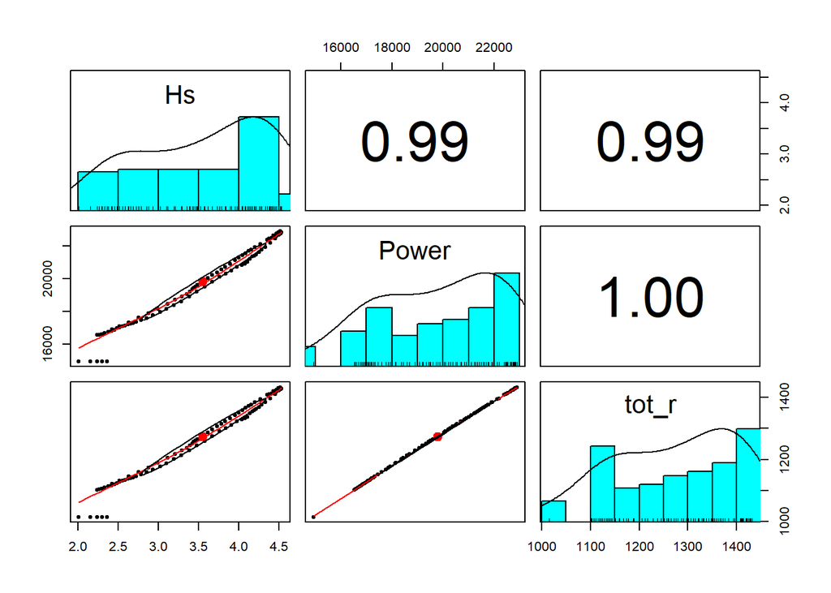

```r
pairs.panels(mydata[1:3])
```

```r
divi=sample(1:nrow(mydata), nrow(mydata)/2)
divi
```

```
##  [1] 44 33 80 27 70 32 90 49 89 74 25 93 22 16 53 69 58 42 56 75 19 54 47  4  2
## [26] 84 26 68 87 31 95 45 66  6 12 23  9 76  1 86 38 18 55 51 96 63 21 24 30
```

This code generates a random sample of row indices from the ‘mydata’ dataset. The function ‘sample()’ randomly selects row indices ranging from 1 to the total number of rows in ‘mydata’. The argument ‘nrow(mydata)/2’ specifies the size of the sample, which is half the number of rows in ‘mydata’. The resulting ‘divi’ variable contains the randomly selected row indices.

```r
part1=mydata[divi,]
part2=mydata[-divi,]
```

This code splits the dataset ‘mydata’ into two parts, ‘part1’ and ‘part2’. ‘part1’ contains the rows indexed by ‘divi’, which is a random sample of row indices obtained previously. These rows are selected from ‘mydata’ using square brackets and the indices in ‘divi’. ‘part2’ contains the remaining rows of ‘mydata’, excluding the rows indexed by ‘divi’, which are denoted by ‘-divi’.

Q1: Classification/ Model Developement

```r
lindis=lda(dt~test1+test2+total_resistance, data=part1)
lindis
```

```
## Call:
## lda(dt ~ test1 + test2 + total_resistance, data = part1)
##
## Prior probabilities of groups:
## Afternoon   Evening   Morning     Night
## 0.2828283 0.1919192 0.2525253 0.2727273
##
## Group means:
##              test1    test2 total_resistance
## Afternoon 3.238998 18816.87         1222.199
## Evening   3.416255 19451.81         1255.045
## Morning   3.823816 20582.28         1313.654
## Night     3.733191 20315.88         1299.695
##
## Coefficients of linear discriminants:
##                           LD1         LD2         LD3
## test1             1.237488626  9.05245356  0.42854540
## test2             0.007904178 -0.00806038  0.02538781
## total_resistance -0.151752797  0.09704165 -0.49322538
##
## Proportion of trace:
##    LD1    LD2    LD3
## 0.8897 0.1031 0.0072
```

The output you provided is from the linear discriminant analysis (LDA) performed in R. LDA is a technique used for classifying observations into groups based on several predictor variables. In this case, the groups are “Afternoon,” “Evening,” “Morning,” and “Night,” and the predictor variables are “test1,” “test2,” and “total_resistance.” Let’s go through the output step by step:

```r
prd=predict(lindis, data=part2)
prd
```

```
## $class
##  [1] Evening   Afternoon Afternoon Afternoon Afternoon Afternoon Afternoon
##  [8] Afternoon Afternoon Afternoon Afternoon Afternoon Afternoon Afternoon
## [15] Afternoon Afternoon Afternoon Afternoon Afternoon Afternoon Afternoon
## [22] Afternoon Afternoon Afternoon Afternoon Afternoon Afternoon Afternoon
## [29] Morning   Morning   Morning   Morning   Morning   Morning   Morning
## [36] Morning   Morning   Morning   Morning   Morning   Morning   Night
## [43] Night     Night     Night     Night     Night     Night     Night
## [50] Night     Night     Night     Night     Night     Night     Night
## [57] Night     Night     Night     Night     Night     Night     Night
## [64] Night     Night     Night     Night     Night     Night     Night
## [71] Night     Night     Night     Night     Afternoon Afternoon Afternoon
## [78] Afternoon Afternoon Afternoon Afternoon Afternoon Afternoon Afternoon
## [85] Afternoon Afternoon Afternoon Afternoon Afternoon Afternoon Afternoon
## [92] Afternoon Afternoon Afternoon Afternoon Afternoon Afternoon Afternoon
```

[output cut: 206 more lines]

```r
attributes(lindis)
```

```
## $names
##  [1] "prior"   "counts"  "means"   "scaling" "lev"     "svd"     "N"
##  [8] "call"    "terms"   "xlevels"
##
## $class
## [1] "lda"
```

These attributes provide various details about the fitted LDA model, including information about class priors, group means, number of observations, model terms, and other properties essential for interpreting and understanding the model.

```r
lindis$prior
```

```
## Afternoon   Evening   Morning     Night
## 0.2828283 0.1919192 0.2525253 0.2727273
```

The result “Afternoon 0.2828283, Evening 0.1919192, Morning 0.2525253, Night 0.2727273” represents the prior probabilities of the groups (time periods) in the Linear Discriminant Analysis (LDA) model stored in the object `lindis`.

- Afternoon has a prior probability of approximately 28.28%.
- Evening has a prior probability of approximately 19.19%.
- Morning has a prior probability of approximately 25.25%.
- Night has a prior probability of approximately 27.27%.

These probabilities indicate the estimated proportions of each group in the dataset before considering any predictor variables. They provide a baseline understanding of the distribution of classes in the dataset and are used as part of the LDA algorithm to calculate the posterior probabilities of group membership for individual observations.

```r
lindis$counts
```

```
## Afternoon   Evening   Morning     Night
##        28        19        25        27
```

The output “Afternoon Evening Morning Night 28 19 25 27” represents the counts of observations in each class (time period) in the training data used to fit the LDA model (lindis). Here’s the breakdown:

These counts provide information about the distribution of classes in the training data. It indicates the number of instances available for each time period, which is essential for understanding the balance or imbalance in the dataset and can impact the model’s performance and predictions.

```r
lindis$means
```

```
##              test1    test2 total_resistance
## Afternoon 3.238998 18816.87         1222.199
## Evening   3.416255 19451.81         1255.045
## Morning   3.823816 20582.28         1313.654
## Night     3.733191 20315.88         1299.695
```

The output shows the means of predictor variables (test1, test2, total_resistance) for each group (time of day) based on the Linear Discriminant Analysis (LDA) model (`lindis`). Here’s an explanation:

- test1, test2, total_resistance: These are the predictor variables used in the LDA model.
- Afternoon, Evening, Morning, Night: These are the groups or categories of the response variable (dt). Each row corresponds to a different time period, and the columns represent the mean values of the predictor variables for observations within that time period.

For example: - In the Afternoon group, the mean value of test1 is approximately 3.239, test2 is around 18816.87, and total_resistance is approximately 1222.199. - Similarly, the mean values for the Evening, Morning, and Night groups are provided in the subsequent rows.

These means provide insights into the average values of predictor variables for different time periods, helping to understand how these variables vary across different groups.

Q2: Model Acceptance

```r
lda.p=predict(lindis, newdata = mydata[,c(1,2,3)])$class
lda.p
```

```
##  [1] Evening   Afternoon Afternoon Afternoon Afternoon Afternoon Afternoon
##  [8] Afternoon Afternoon Afternoon Afternoon Afternoon Afternoon Afternoon
## [15] Afternoon Afternoon Afternoon Afternoon Afternoon Afternoon Afternoon
## [22] Afternoon Afternoon Afternoon Afternoon Afternoon Afternoon Afternoon
## [29] Morning   Morning   Morning   Morning   Morning   Morning   Morning
## [36] Morning   Morning   Morning   Morning   Morning   Morning   Night
## [43] Night     Night     Night     Night     Night     Night     Night
## [50] Night     Night     Night     Night     Night     Night     Night
## [57] Night     Night     Night     Night     Night     Night     Night
## [64] Night     Night     Night     Night     Night     Night     Night
## [71] Night     Night     Night     Night     Afternoon Afternoon Afternoon
## [78] Afternoon Afternoon Afternoon Afternoon Afternoon Afternoon Afternoon
## [85] Afternoon Afternoon Afternoon Afternoon Afternoon Afternoon Afternoon
## [92] Afternoon Afternoon Afternoon Afternoon Afternoon Afternoon Afternoon
## [99] Afternoon
## Levels: Afternoon Evening Morning Night
```

The result is a vector (lda.p) containing the predicted class labels for each observation in the new data. The output displays the predicted time of day for each observation, with each observation classified into one of four categories: Afternoon, Evening, Morning, or Night. The Levels section at the end shows the unique levels or categories of the predicted class labels. Overall, the code effectively applies the LDA model to new data and provides predictions for the time of day based on the given predictors.

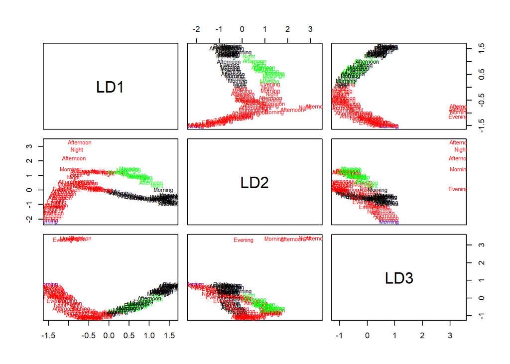

```r
# Generate colors based on the predicted classes
colors <- c("red", "blue", "green") # Adjust the colors as needed
predicted_colors <- colors[as.integer(predict(lindis)$class)]

# Plot the color plot
plot(lindis, col = predicted_colors)
```

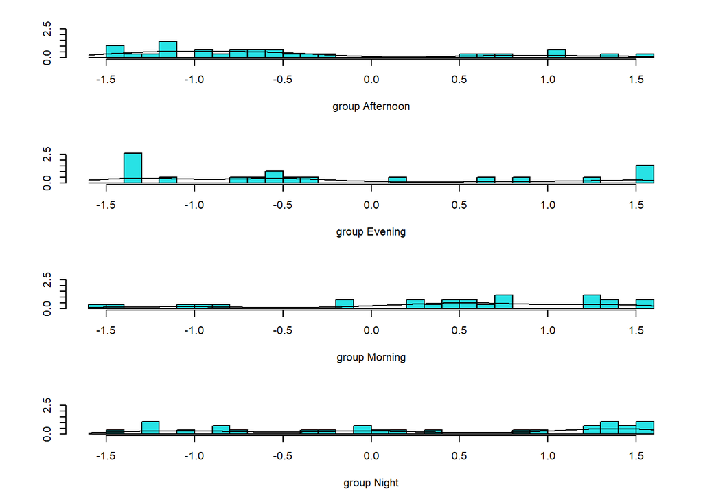

```r
par(mar = c(5, 5, 2, 2))  # Adjust the margins (bottom, left, top, right)
plot(lindis, dimen = 1, type = "both")
```

The image shows four separate histograms, each representing a different group labelled as “Afternoon,” “Evening,” “Morning,” and “Night.” These histograms are plotted against what appears to be a density curve that fits the distribution of the histogram bars.

The x-axis seems to represent some continuous variable, while the y-axis represents the frequency or probability density of the observations. The differences in the shapes of the histograms and density curves across the four groups suggest variations in the underlying distribution of the variable being measured at different times of the day. Without more context or specific labeling of the axes, we cannot determine what the variable represents or the units of measurement.

```r
ct1=table(lda.p, mydata[,12])
ct1
```

```
##
## lda.p       Afternoon Evening Morning Night
##   Afternoon        21      13       6    12
##   Evening           0       0       1     0
##   Morning           3       0       6     4
##   Night             4       6      12    11
```

```r
diag(prop.table(ct1, 1))
```

```
## Afternoon   Evening   Morning     Night
## 0.4038462 0.0000000 0.4615385 0.3333333
```

Q3: Prediction

```r
actual <- mydata$dtime
predicted <- predict(lindis)$class
is_miss <- actual != predicted
is_miss
```

```
##  [1]  TRUE  TRUE FALSE FALSE FALSE  TRUE  TRUE  TRUE FALSE  TRUE  TRUE FALSE
## [13] FALSE FALSE FALSE  TRUE  TRUE FALSE  TRUE  TRUE  TRUE FALSE  TRUE FALSE
## [25]  TRUE  TRUE  TRUE  TRUE FALSE  TRUE FALSE FALSE FALSE  TRUE FALSE FALSE
## [37]  TRUE  TRUE  TRUE  TRUE  TRUE  TRUE  TRUE  TRUE  TRUE FALSE  TRUE FALSE
## [49] FALSE FALSE  TRUE  TRUE FALSE  TRUE  TRUE  TRUE FALSE FALSE  TRUE FALSE
## [61]  TRUE FALSE  TRUE  TRUE  TRUE  TRUE  TRUE  TRUE  TRUE  TRUE  TRUE  TRUE
## [73] FALSE FALSE  TRUE  TRUE FALSE  TRUE  TRUE  TRUE FALSE FALSE  TRUE FALSE
## [85]  TRUE FALSE FALSE  TRUE FALSE FALSE  TRUE  TRUE  TRUE  TRUE FALSE  TRUE
## [97] FALSE  TRUE  TRUE
```

This code is creating a vector `actual` containing the actual values of the `dtime` variable from the `mydata` dataset. Then, it predicts the class labels using the Linear Discriminant Analysis (LDA) model `lindis` for the `dtime` variable, and stores them in the `predicted` vector.

After that, it compares the `actual` and `predicted` vectors element-wise to check for mismatches. It creates a logical vector `is_miss` which is `TRUE` for elements where the actual value does not match the predicted value, and `FALSE` otherwise. This vector will be used to identify the observations where the LDA model made incorrect predictions.

```r
# Convert actual and predicted to character vectors
a <- as.character(actual[is_miss])
c <- as.character(predicted[is_miss])
# Extract posterior probabilities and round them
p <- round(predict(lindis, newdata = mydata)$posterior[is_miss], 2)
p
```

```
##   [1] 0.36 0.37 0.39 0.39 0.39 0.40 0.40 0.42 0.42 0.42 0.41 0.41 0.38 0.35 0.33
##  [16] 0.30 0.29 0.26 0.22 0.20 0.19 0.18 0.17 0.15 0.13 0.12 0.11 0.11 0.12 0.13
##  [31] 0.13 0.13 0.13 0.12 0.11 0.11 0.14 0.15 0.17 0.18 0.18 0.19 0.20 0.21 0.22
##  [46] 0.24 0.28 0.29 0.31 0.32 0.33 0.35 0.37 0.40 0.41 0.40 0.40 0.39 0.47 0.45
##  [61] 0.42 0.36 0.36 0.31 0.30 0.29 0.28 0.27 0.22 0.21 0.18 0.18 0.17 0.16 0.15
##  [76] 0.15 0.15 0.15 0.14 0.13 0.13 0.13 0.13 0.13 0.13 0.14 0.14 0.14 0.14 0.14
##  [91] 0.16 0.16 0.16 0.16 0.16 0.15 0.16 0.17 0.17 0.18 0.18 0.19 0.19 0.19 0.19
## [106] 0.19 0.20 0.20 0.20 0.21 0.21 0.21 0.20 0.19 0.21 0.26 0.28 0.30 0.32 0.11
## [121] 0.16 0.22 0.11 0.11 0.13 0.13 0.13 0.14 0.14 0.16 0.17 0.18 0.19 0.20 0.22
## [136] 0.25 0.26 0.27 0.28 0.30 0.33 0.34 0.34 0.35 0.35 0.36 0.36 0.37 0.37 0.37
## [151] 0.36 0.35 0.35 0.35 0.35 0.35 0.36 0.36 0.34 0.33 0.32 0.32 0.31 0.31 0.30
## [166] 0.29 0.29 0.28 0.26 0.25 0.23 0.23 0.22 0.22 0.21 0.19 0.15 0.14 0.13 0.12
## [181] 0.17 0.15 0.14 0.16 0.17 0.18 0.18 0.18 0.18 0.19 0.20 0.20 0.21 0.22 0.22
## [196] 0.24 0.25 0.26 0.27 0.28 0.30 0.32 0.33 0.33 0.34 0.35 0.36 0.37 0.37 0.38
## [211] 0.38 0.37 0.36 0.36 0.36 0.36 0.37 0.38 0.37 0.35 0.34 0.33 0.32 0.32 0.31
## [226] 0.31 0.30 0.29 0.29 0.26 0.26 0.25 0.24 0.24 0.23 0.23 0.21 0.19 0.18 0.17
## [241] 0.17 0.25 0.24 0.22
```

It compares the actual and predicted vectors element-wise to check for mismatches. It creates a logical vector is_miss which is TRUE for elements where the actual value does not match the predicted value, and FALSE otherwise. This vector will be used to identify the observations where the LDA model made incorrect predictions.

Q4: Model Accuracy

```r
# Compute confusion matrix
conf_matrix <- table(actual, predicted)

# Compute accuracy
accuracy <- sum(diag(conf_matrix)) / sum(conf_matrix)

# Print accuracy
print(paste("Model Accuracy:", round(accuracy * 100, 2), "%"))
```

```
## [1] "Model Accuracy: 38.38 %"
```

Q5 Residuals

```r
# Compute residuals
residuals <- lindis$residuals
residuals
```

[output not shown]

```r
# Combine the data into a data frame
result <- cbind(p, actual = a, predicted = c)
result
```

```
##        p      actual      predicted
##   [1,] "0.36" "Morning"   "Evening"
##   [2,] "0.37" "Morning"   "Afternoon"
##   [3,] "0.39" "Evening"   "Afternoon"
##   [4,] "0.39" "Evening"   "Afternoon"
##   [5,] "0.39" "Evening"   "Afternoon"
##   [6,] "0.4"  "Night"     "Afternoon"
##   [7,] "0.4"  "Night"     "Afternoon"
##   [8,] "0.42" "Night"     "Afternoon"
##   [9,] "0.42" "Morning"   "Afternoon"
##  [10,] "0.42" "Night"     "Afternoon"
##  [11,] "0.41" "Night"     "Afternoon"
##  [12,] "0.41" "Evening"   "Afternoon"
##  [13,] "0.38" "Evening"   "Afternoon"
##  [14,] "0.35" "Night"     "Afternoon"
```

[output cut: 230 more lines]